# Libraries

```python
import numpy as np
from sklearn import datasets
from sklearn.preprocessing import StandardScaler
from sklearn.model_selection import train_test_split
from sklearn.metrics import mean_squared_error,accuracy_score,classification_report
import skfuzzy as fuzz
import matplotlib.pyplot as plt
import torch
import torch.nn as nn
import torch.optim as optim
import pandas
from sklearn.decomposition import PCA
```

# Exercise 1: Diabetes Dataset (Regression)

**Importing the dataset, train test splitting and normalization:** The first step is to import and prepare the dataset. The percentage for spliting tain and test data depends on the size of total samples, in this case as 442 samples is considered as relatively small, the dataset should be split into a test size of approximately 20% to 30%.

```python
from sklearn import datasets
#load dataset
diabetes= datasets.load_diabetes(as_frame=True)
X=diabetes.data
y=diabetes.target

print("X head:\n", X.head())
print("y head:\n", y.head())

#train test spliting
test_size=0.2
Xtr, Xte, ytr, yte = train_test_split(X, y, test_size=test_size, random_state=42)

# Standardize features
scaler=StandardScaler()
Xtr= scaler.fit_transform(Xtr)
Xte= scaler.transform(Xte)
```

```
X head:
         age       sex       bmi        bp        s1        s2        s3  \
0  0.038076  0.050680  0.061696  0.021872 -0.044223 -0.034821 -0.043401
1 -0.001882 -0.044642 -0.051474 -0.026328 -0.008449 -0.019163  0.074412
2  0.085299  0.050680  0.044451 -0.005670 -0.045599 -0.034194 -0.032356
3 -0.089063 -0.044642 -0.011595 -0.036656  0.012191  0.024991 -0.036038
4  0.005383 -0.044642 -0.036385  0.021872  0.003935  0.015596  0.008142

         s4        s5        s6
0 -0.002592  0.019907 -0.017646
1 -0.039493 -0.068332 -0.092204
2 -0.002592  0.002861 -0.025930
3  0.034309  0.022688 -0.009362
4 -0.002592 -0.031988 -0.046641
y head:
 0    151.0
1     75.0
2    141.0
3    206.0
4    135.0
Name: target, dtype: float64
```

When clustering we have to define various things to see whch is better for our model such as: Number of clusters , this can be verified by the Fuzzy partition coefficient (FPC) Fuzziness parameter, where m=1 (hard clustering) and m>1 (fuzzy clustering, points can belong to multiple clusters with different degrees), i left the value of m as 2 as it is the default value for the fuzziness coefficient. the value defined for error tolerance, maximum interations also affects the model differently.

```
Number of clusters: 2, Fuzzy partition coefficient (FPC): 0.8556
```

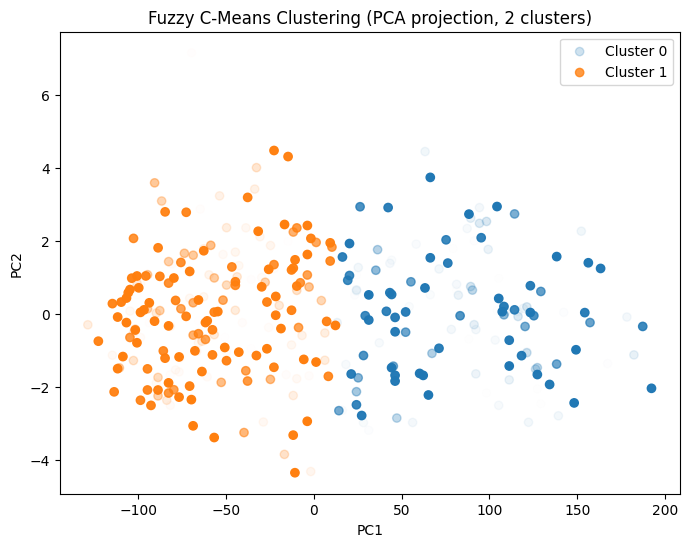

```
Number of clusters: 3, Fuzzy partition coefficient (FPC): 0.8077
```

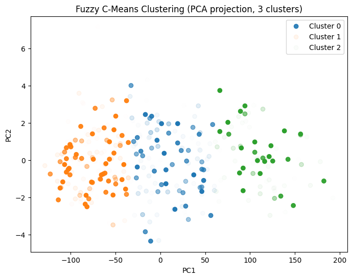

```
Number of clusters: 4, Fuzzy partition coefficient (FPC): 0.7803
```

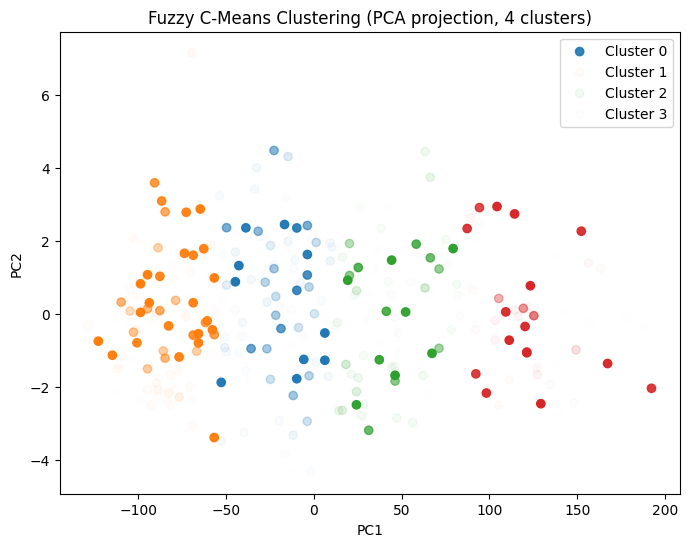

```python
m = 2  # fuzziness coefficient

# Concatenate target for clustering
Xexp = np.concatenate([Xtr, ytr.to_numpy().reshape(-1, 1)], axis=1)
#Xexp = Xtr

# Transpose data for skfuzzy (expects features x samples)
Xexp_T = Xexp.T

# Reduce data to 2D for plotting (use same data you clustered on)
Xexp_2d = PCA(n_components=2).fit_transform(Xexp)

# Try different numbers of clusters
for n_clusters in [2, 3, 4]:
    # Fuzzy C-means clustering
    centers, u, u0, d, jm, p, fpc = fuzz.cluster.cmeans(
        Xexp_T, n_clusters, m=m, error=0.005, maxiter=1000, init=None
    )

    # Compute sigma (spread) for each cluster
    sigmas = []
    for j in range(n_clusters):
        u_j = u[j, :] ** m
        var_j = np.average((Xexp - centers[j])**2, axis=0, weights=u_j)
        sigma_j = np.sqrt(var_j)
        sigmas.append(sigma_j)
    sigmas = np.array(sigmas)

    # Hard clustering from fuzzy membership
    cluster_labels = np.argmax(u, axis=0)

    print(f"Number of clusters: {n_clusters}, Fuzzy partition coefficient (FPC): {fpc:.4f}")

    # Plot PCA projection
    plt.figure(figsize=(8,6))
    for j in range(n_clusters):
        plt.scatter(
            Xexp_2d[cluster_labels == j, 0],
            Xexp_2d[cluster_labels == j, 1],
            alpha=u[j, :],
            label=f'Cluster {j}'
        )
    plt.title(f"Fuzzy C-Means Clustering (PCA projection, {n_clusters} clusters)")
    plt.xlabel("PC1")
    plt.ylabel("PC2")
    plt.legend()
    plt.show()
```

```python
m_values = [1.5, 2.0, 2.5, 3.0]   # try different fuzziness coefficients
cluster_options = [2, 3, 4]       # number of clusters to test

# Make sure ytr is numpy before concatenating
if hasattr(ytr, "to_numpy"):
    y_arr = ytr.to_numpy().reshape(-1, 1)
else:
    y_arr = np.array(ytr).reshape(-1, 1)

Xexp = np.concatenate([Xtr, y_arr], axis=1)
Xexp_T = Xexp.T

for m in m_values:
    print(f"\n=== Results for m = {m} ===")
    for n_clusters in cluster_options:
        centers, u, u0, d, jm, p, fpc = fuzz.cluster.cmeans(
            Xexp_T, n_clusters, m=m, error=0.005, maxiter=1000, init=None
        )
        print(f"Clusters: {n_clusters}, FPC: {fpc:.4f}")
```

```
=== Results for m = 1.5 ===
Clusters: 2, FPC: 0.9397
Clusters: 3, FPC: 0.9217
Clusters: 4, FPC: 0.9153

=== Results for m = 2.0 ===
Clusters: 2, FPC: 0.8556
Clusters: 3, FPC: 0.8077
Clusters: 4, FPC: 0.7803

=== Results for m = 2.5 ===
Clusters: 2, FPC: 0.7764
Clusters: 3, FPC: 0.6899
Clusters: 4, FPC: 0.6400

=== Results for m = 3.0 ===
Clusters: 2, FPC: 0.7139
Clusters: 3, FPC: 0.5971
Clusters: 4, FPC: 0.5301
```

We can conclude by observing the graphs and the fpc values that by addig clusters the model is getting worse so the will keep the number of clusters as 2, we conclude that the best model is for when we have 2 clusters and value for m=1.5

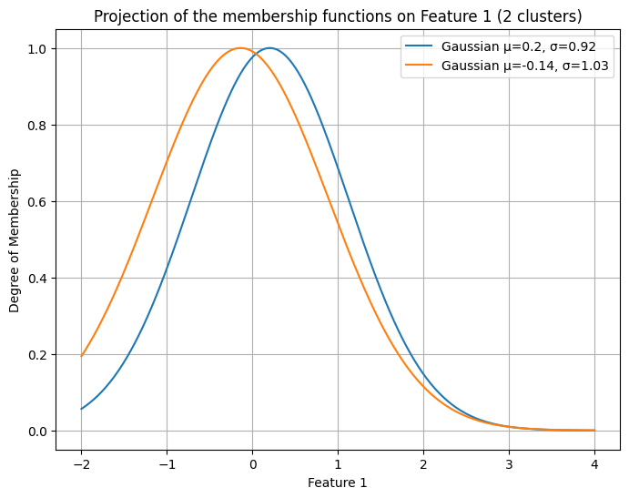

```python
# Gaussian formula
def gaussian(x, mu, sigma):
    return np.exp(-0.5 * ((x - mu) / sigma) ** 2)

# Run clustering again with 2 clusters and m=1.5 (best choice)
best_n_clusters = 2
centers, u, u0, d, jm, p, fpc = fuzz.cluster.cmeans(
    Xexp_T, best_n_clusters, m=1.5, error=0.005, maxiter=1000, init=None
)

# Compute sigmas for the 2 clusters
sigmas = []
for j in range(best_n_clusters):
    u_j = u[j, :] ** m
    var_j = np.average((Xexp - centers[j]) ** 2, axis=0, weights=u_j)
    sigma_j = np.sqrt(var_j)
    sigmas.append(sigma_j)
sigmas = np.array(sigmas)

# Gaussian curves
lin = np.linspace(-2, 4, 500)
plt.figure(figsize=(8, 6))

y_aux = []
for j in range(best_n_clusters):
    # Compute curves
    y_aux.append(gaussian(lin, centers[j, 0], sigmas[j, 0]))
    # Plot
    plt.plot(
        lin,
        y_aux[j],
        label=f"Gaussian μ={np.round(centers[j, 0], 2)}, σ={np.round(sigmas[j, 0], 2)}"
    )

plt.title("Projection of the membership functions on Feature 1 (2 clusters)")
plt.xlabel("Feature 1")
plt.ylabel("Degree of Membership")
plt.legend()
plt.grid(True)
plt.show()
```

The overlap suggests the two clusters are not extremely well-separated on this feature alone. That doesn’t mean the clustering is bad — it may be that separation is clearer when you consider other features or combinations of features (multidimensional).

You plotted membership functions projected on feature 1 (after the standardization you applied). Because features were standardized, the μ values are in units of standard deviations.

If your goal is to find two very distinct groups, this plot suggests feature 1 alone won’t give that. If your goal is to capture gradual changes or soft membership, this looks reasonable.

```python
# ---------------------------
# Gaussian Membership Function
# ---------------------------
class GaussianMF(nn.Module):
    def __init__(self, centers, sigmas, agg_prob):
        super().__init__()
        self.centers = nn.Parameter(torch.tensor(centers, dtype=torch.float32))
        self.sigmas = nn.Parameter(torch.tensor(sigmas, dtype=torch.float32))
        self.agg_prob=agg_prob

    def forward(self, x):
        # Expand for broadcasting
        # x: (batch, 1, n_dims), centers: (1, n_rules, n_dims), sigmas: (1, n_rules, n_dims)
        diff = abs((x.unsqueeze(1) - self.centers.unsqueeze(0))/self.sigmas.unsqueeze(0)) #(batch, n_rules, n_dims)

        # Aggregation
        if self.agg_prob:
            dist = torch.norm(diff, dim=-1)  # (batch, n_rules) # probablistic intersection
        else:
            dist = torch.max(diff, dim=-1).values  # (batch, n_rules) # min intersection (min instersection of normal funtion is the same as the max on dist)

        return torch.exp(-0.5 * dist ** 2)


# ---------------------------
# TSK Model
# ---------------------------
class TSK(nn.Module):
    def __init__(self, n_inputs, n_rules, centers, sigmas,agg_prob=False):
        super().__init__()
        self.n_inputs = n_inputs
        self.n_rules = n_rules

        # Antecedents (Gaussian MFs)

        self.mfs=GaussianMF(centers, sigmas,agg_prob)

        # Consequents (linear functions of inputs)
        # Each rule has coeffs for each input + bias
        self.consequents = nn.Parameter(
            torch.randn(n_inputs + 1,n_rules)
        )

    def forward(self, x):
        # x: (batch, n_inputs)
        batch_size = x.shape[0]

        # Compute membership values for each input feature
        # firing_strengths: (batch, n_rules)
        firing_strengths = self.mfs(x)

        # Normalize memberships
        # norm_fs: (batch, n_rules)
        norm_fs = firing_strengths / (firing_strengths.sum(dim=1, keepdim=True) + 1e-9)

        # Consequent output (linear model per rule)
        x_aug = torch.cat([x, torch.ones(batch_size, 1)], dim=1)  # add bias

        rule_outputs = torch.einsum("br,rk->bk", x_aug, self.consequents)  # (batch, rules)
        # Weighted sum
        output = torch.sum(norm_fs * rule_outputs, dim=1, keepdim=True)

        return output, norm_fs, rule_outputs
```

```python
# ---------------------------
# Least Squares Solver for Consequents (TSK)
# ---------------------------
def train_ls(model, X, y):
    with torch.no_grad():
        _, norm_fs, _ = model(X)

        # Design matrix for LS: combine normalized firing strengths with input
        X_aug = torch.cat([X, torch.ones(X.shape[0], 1)], dim=1)

        Phi = torch.einsum("br,bi->bri", X_aug, norm_fs).reshape(X.shape[0], -1)

        # Solve LS: consequents = (Phi^T Phi)^-1 Phi^T y

        theta= torch.linalg.lstsq(Phi, y).solution


        model.consequents.data = theta.reshape(model.consequents.shape)
```

```python
#build model
Xtr = torch.tensor(Xtr, dtype=torch.float32)
ytr = torch.tensor(ytr, dtype=torch.float32).view(-1, 1)
Xte = torch.tensor(Xte, dtype=torch.float32)
yte = torch.tensor(yte, dtype=torch.float32).view(-1, 1)

best_n_clusters = 2

model = TSK(
    n_inputs=Xtr.shape[1],
    n_rules=best_n_clusters,
    centers=centers[:, :-1],
    sigmas=sigmas[:, :-1],
    agg_prob=False
)
```

```python
# Training with LS:
train_ls(model, Xtr, ytr.reshape(-1,1))
```

```python
y_pred, _, _=model(Xte)
#performance metric for regression
print(f'MSE:{mean_squared_error(yte.detach().numpy(),y_pred.detach().numpy())}') #regression
```

```
MSE:2536.402587890625
```

# Exercise 2: Pima Indians Diabetes Dataset (Classification)

Loading of dataset:

```python
from sklearn.datasets import fetch_openml

diabetes = fetch_openml("diabetes", version=1, as_frame=True)
X=diabetes.data
y=diabetes.target

#Making sure the data is being correctly loaded:
print("X head:\n", X.head())
print("y head:\n", y.head())

#train test spliting
test_size=0.2
Xtr, Xte, ytr, yte = train_test_split(X, y, test_size=test_size, random_state=42)

# Standardize features
scaler=StandardScaler()
Xtr= scaler.fit_transform(Xtr)
Xte= scaler.transform(Xte)
```

```
X head:
    preg  plas  pres  skin  insu  mass   pedi  age
0     6   148    72    35     0  33.6  0.627   50
1     1    85    66    29     0  26.6  0.351   31
2     8   183    64     0     0  23.3  0.672   32
3     1    89    66    23    94  28.1  0.167   21
4     0   137    40    35   168  43.1  2.288   33
y head:
 0    tested_positive
1    tested_negative
2    tested_positive
3    tested_negative
4    tested_positive
Name: class, dtype: category
Categories (2, object): ['tested_negative', 'tested_positive']
```

**Clustering:** In the case of regression we had to test the model with a different number of clusters as to conclude which number would model the model the best. But in this case of classification we can only use 2 clusters because the target variable only has two possible outcomes (tested negative or tested positive).

```python
from sklearn.preprocessing import StandardScaler

# Number of clusters
n_clusters = 2
m = 2

# Convert target to numerical values
ytr_num = ytr.map({'tested_negative': 0, 'tested_positive': 1}).to_numpy()

# Optional: standardize the target
scaler_y = StandardScaler()
ytr_scaled = scaler_y.fit_transform(ytr_num.reshape(-1, 1))

# Concatenate standardized features with standardized target
Xexp = np.concatenate([Xtr, ytr_scaled], axis=1)

# Transpose data for skfuzzy (expects features x samples)
Xexp_T = Xexp.T

# Fuzzy C-means clustering
centers, u, u0, d, jm, p, fpc = fuzz.cluster.cmeans(
    Xexp_T, n_clusters, m=m, error=0.005, maxiter=1000, init=None
)
centers.shape
```

```
(2, 9)
```

```python
# Compute sigma (spread) for each cluster
sigmas = []
for j in range(n_clusters):
    # membership weights for cluster j, raised to m
    u_j = u[j, :] ** m
    # weighted variance for each feature
    var_j = np.average((Xexp - centers[j])**2, axis=0, weights=u_j)
    sigma_j = np.sqrt(var_j)
    sigmas.append(sigma_j)
sigmas=np.array(sigmas)
```

```
Fuzzy partition coefficient (FPC): 0.5000014893433536
```

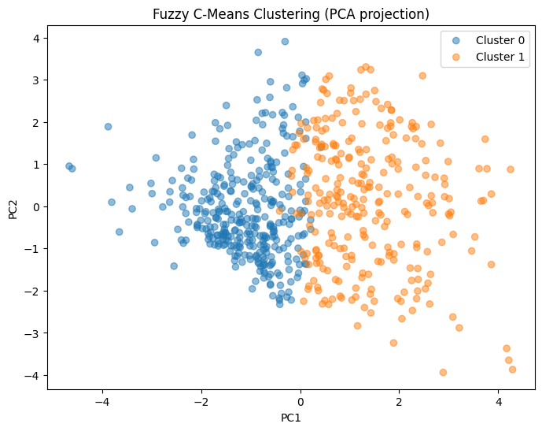

```python
from sklearn.decomposition import PCA

# Reduce data to 2D for plotting (use same data you clustered on)
Xexp_2d = PCA(n_components=2).fit_transform(Xexp)


# Hard clustering from fuzzy membership
cluster_labels = np.argmax(u, axis=0)
print("Fuzzy partition coefficient (FPC):", fpc)

# Plot two principal components with fuzzy membership
plt.figure(figsize=(8,6))
for j in range(n_clusters):
    plt.scatter(
        Xexp_2d[cluster_labels == j, 0],    # PCA feature 1
        Xexp_2d[cluster_labels == j, 1],    # PCA feature 2
        alpha=u[j, :],                      # transparency ~ membership
        label=f'Cluster {j}'
    )

plt.title("Fuzzy C-Means Clustering (PCA projection)")
plt.xlabel("PC1")
plt.ylabel("PC2")
plt.legend()
plt.show()
```

```python
# Test different m values for FPC
m_values = np.arange(1.1, 3.1, 0.1)  # Example: m from 1.1 to 3.0
fpc_results = []

for m in m_values:
    centers, u, u0, d, jm, p, fpc = fuzz.cluster.cmeans(
        Xexp_T, n_clusters, m=m, error=0.005, maxiter=1000, init=None
    )
    fpc_results.append((m, fpc))

# Print FPC for each m
for m, fpc in fpc_results:
    print(f"m = {m:.1f}, FPC = {fpc:.4f}")

# Identify m with the highest FPC
best_m, best_fpc = max(fpc_results, key=lambda x: x[1])
print(f"\nBest m: {best_m:.1f} with FPC = {best_fpc:.4f}")
```

```
m = 1.1, FPC = 0.9292
m = 1.2, FPC = 0.8573
m = 1.3, FPC = 0.7903
m = 1.4, FPC = 0.7301
m = 1.5, FPC = 0.6777
m = 1.6, FPC = 0.6333
m = 1.7, FPC = 0.5971
m = 1.8, FPC = 0.5679
m = 1.9, FPC = 0.5450
m = 2.0, FPC = 0.5271
m = 2.1, FPC = 0.5132
m = 2.2, FPC = 0.5001
m = 2.3, FPC = 0.5001
m = 2.4, FPC = 0.5000
m = 2.5, FPC = 0.5000
m = 2.6, FPC = 0.5000
m = 2.7, FPC = 0.5000
m = 2.8, FPC = 0.5000
m = 2.9, FPC = 0.5000
m = 3.0, FPC = 0.5000

Best m: 1.1 with FPC = 0.9292
```

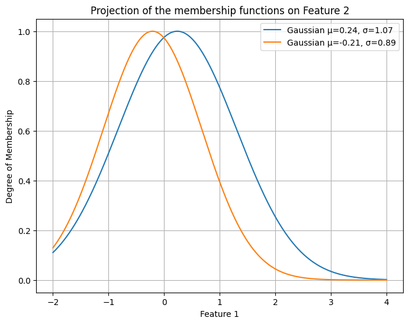

```python
# Gaussian formula
def gaussian(x, mu, sigma):
    return np.exp(-0.5 * ((x - mu)/sigma)**2)

lin=np.linspace(-2, 4, 500)
plt.figure(figsize=(8,6))

y_aux=[]
for j in range(n_clusters):
# Compute curves
    y_aux.append(gaussian(lin, centers[j,0], sigmas[j,0]))

# Plot
    plt.plot(lin, y_aux[j], label=f"Gaussian μ={np.round(centers[j,0],2)}, σ={np.round(sigmas[j,0],2)}")

plt.title("Projection of the membership functions on Feature 2")
plt.xlabel("Feature 1")
plt.ylabel("Degree of Membership")
plt.legend()
plt.grid(True)
plt.show()
```

```python
# ---------------------------
# Gaussian Membership Function
# ---------------------------
class GaussianMF(nn.Module):
    def __init__(self, centers, sigmas, agg_prob):
        super().__init__()
        self.centers = nn.Parameter(torch.tensor(centers, dtype=torch.float32))
        self.sigmas = nn.Parameter(torch.tensor(sigmas, dtype=torch.float32))
        self.agg_prob=agg_prob

    def forward(self, x):
        # Expand for broadcasting
        # x: (batch, 1, n_dims), centers: (1, n_rules, n_dims), sigmas: (1, n_rules, n_dims)
        diff = abs((x.unsqueeze(1) - self.centers.unsqueeze(0))/self.sigmas.unsqueeze(0)) #(batch, n_rules, n_dims)

        # Aggregation
        if self.agg_prob:
            dist = torch.norm(diff, dim=-1)  # (batch, n_rules) # probablistic intersection
        else:
            dist = torch.max(diff, dim=-1).values  # (batch, n_rules) # min intersection (min instersection of normal funtion is the same as the max on dist)

        return torch.exp(-0.5 * dist ** 2)


# ---------------------------
# TSK Model
# ---------------------------
class TSK(nn.Module):
    def __init__(self, n_inputs, n_rules, centers, sigmas,agg_prob=False):
        super().__init__()
        self.n_inputs = n_inputs
        self.n_rules = n_rules

        # Antecedents (Gaussian MFs)

        self.mfs=GaussianMF(centers, sigmas,agg_prob)

        # Consequents (linear functions of inputs)
        # Each rule has coeffs for each input + bias
        self.consequents = nn.Parameter(
            torch.randn(n_inputs + 1,n_rules)
        )

    def forward(self, x):
        # x: (batch, n_inputs)
        batch_size = x.shape[0]

        # Compute membership values for each input feature
        # firing_strengths: (batch, n_rules)
        firing_strengths = self.mfs(x)

        # Normalize memberships
        # norm_fs: (batch, n_rules)
        norm_fs = firing_strengths / (firing_strengths.sum(dim=1, keepdim=True) + 1e-9)

        # Consequent output (linear model per rule)
        x_aug = torch.cat([x, torch.ones(batch_size, 1)], dim=1)  # add bias

        rule_outputs = torch.einsum("br,rk->bk", x_aug, self.consequents)  # (batch, rules)
        # Weighted sum
        output = torch.sum(norm_fs * rule_outputs, dim=1, keepdim=True)

        return output, norm_fs, rule_outputs
```

```python
# ---------------------------
# Least Squares Solver for Consequents (TSK)
# ---------------------------
def train_ls(model, X, y):
    with torch.no_grad():
        _, norm_fs, _ = model(X)

        # Design matrix for LS: combine normalized firing strengths with input
        X_aug = torch.cat([X, torch.ones(X.shape[0], 1)], dim=1)

        Phi = torch.einsum("br,bi->bri", X_aug, norm_fs).reshape(X.shape[0], -1)

        # Solve LS: consequents = (Phi^T Phi)^-1 Phi^T y

        theta= torch.linalg.lstsq(Phi, y).solution


        model.consequents.data = theta.reshape(model.consequents.shape)
```

```python
centers_features = centers[:, :Xtr.shape[1]]
sigmas_features  = sigmas[:, :Xtr.shape[1]]

print(centers_features.shape)
print(sigmas_features.shape)

model = TSK(
    n_inputs=Xtr.shape[1],
    n_rules=n_clusters,
    centers=centers_features,
    sigmas=sigmas_features,
    agg_prob=False
)
```

```
(2, 8)
(2, 8)
```

```python
Xtr_t = torch.tensor(Xtr, dtype=torch.float32).clone().detach()
ytr_num = ytr.map({'tested_negative': 0, 'tested_positive': 1}).values
ytr_t = torch.tensor(ytr_num.reshape(-1,1), dtype=torch.float32).clone().detach()
# Training with LS:
train_ls(model, Xtr_t, ytr_t)
```

```python
# Convert test features to PyTorch tensor
Xte_t = torch.tensor(Xte, dtype=torch.float32)

# Convert test labels to numeric and then to PyTorch tensor
yte_num = yte.map({'tested_negative': 0, 'tested_positive': 1}).values
yte_t = torch.tensor(yte_num.reshape(-1,1), dtype=torch.float32)

# Make predictions
y_pred, _, _ = model(Xte_t)

# Compute classification accuracy
acc = accuracy_score(yte_t.detach().numpy(), (y_pred.detach().numpy() > 0.5))
print(f'ACC: {acc}')
```

```
ACC: 0.7402597402597403
```